# Project: Investigate a Dataset (European Soccer Analysts)

- Introduction
- Data Wrangling
- Exploratory Data Analysis
- Conclusions

## Introduction

> This soccer database comes from Kaggle and is well suited for data analysis and machine learning. It contains data for soccer matches, players, and teams from several European countries from 2008 to 2016.

## Question:

> Which players had the most penalties?

> Does improving speed have relationship with Creation of Shooting in Team Attributes?

> Does the preferred foot affect the ball control of player attributes?

> What team attributes lead to the most victories?

```python
# First, we will set up import statements for all of the packages that plan to use.
import pandas as pd
import matplotlib.pyplot as plt
%matplotlib inline
```

## Data Wrangling

### General Properties

```python
#Loading data
df_match = pd.read_csv('Match.csv')
df_player = pd.read_csv('Player.csv')
df_player_att = pd.read_csv('Player_Attributes.csv')
df_team = pd.read_csv('Team.csv')
df_team_att = pd.read_csv('Team_Attributes.csv')
```

```python
df_player_att.info()
```

```python
df_player.info()
```

```python
df_match.info()
```

```python
df_team.info()
```

```python
df_team_att.info()
```

### Data Cleaning (Missing of the Penalties rate)

```python
# Cleaning data of penalties due to missing value.
df_player_att.isnull().sum()
```

```python
mean_pen = df_player_att['penalties'].mean()
mean_pen
```

```python
df_player_att['penalties'].fillna(mean_pen, inplace = True)
```

```python
#Check the null value again
df_player_att['penalties'].isnull().sum()
```

## Exploratory Data Analysis

### Research Question 1 (Which players had the most penalties?)

```python
# Find the best rate in penalties
best_pen = df_player_att['penalties'].max()
```

```python
# Find the id and the infomation of the best player
best_player = df_player_att[df_player_att['penalties']== best_pen]
id_best = best_player['player_api_id'].unique().tolist()
df_player[df_player['player_api_id'] == id_best[0]]
```

|  | id | player_api_id | player_name | player_fifa_api_id | birthday | height | weight |
| --- | --- | --- | --- | --- | --- | --- | --- |
| 8967 | 8981 | 39225 | Rickie Lambert | 13879 | 1982-02-16 00:00:00 | 187.96 | 170 |

### Research Question 2 (Does improving speed have relationship with Creation of Shooting in Team Attributes?)

[figure not shown]

```python
#df_team_att.plot(x='buildUpPlaySpeed', y='chanceCreationShooting', kind = 'scatter', figsize = (8,8));
```

Based on this result, there is no correlation between BuildPlaySpeed and chanceCreationShooting in Team Attributes

### Research Question 3 (Does the preferred foot affect the ball control of player attributes?)

```python
# We will find out in preferred_foot of the player
#Right foot:
df_r = df_player_att[df_player_att['preferred_foot'] == 'right']

#Left foot:
df_l = df_player_att[df_player_att['preferred_foot'] == 'left']
```

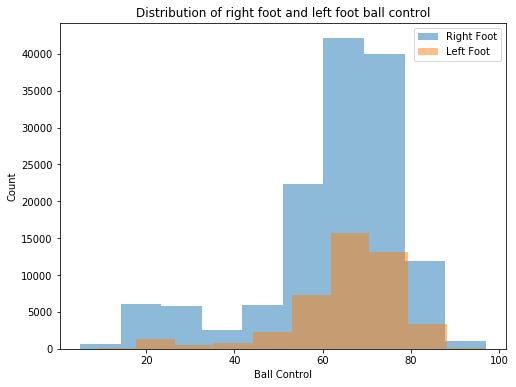

```python
fig, ax=plt.subplots(figsize = (8,6))
ax.hist(df_r['ball_control'], alpha = 0.5, label ='Right Foot')
ax.hist(df_l['ball_control'], alpha = 0.5, label ='Left Foot')
ax.set_title('Distribution of right foot and left foot ball control')
ax.set_xlabel('Ball Control')
ax.set_ylabel('Count')
ax.legend(loc = 'upper right')
```

### Research Question 4 (What team attributes lead to the most victories?)

```python
# Continue to explore the data to address your additional research
#   questions. Add more headers as needed if you have more questions to
#   investigate.
team_win = df_match.filter(['home_team_api_id','home_team_goal','away_team_goal'], axis=1)
```

```python
#Check dataframe.
team_win.info()
```

```
<class 'pandas.core.frame.DataFrame'>
RangeIndex: 25979 entries, 0 to 25978
Data columns (total 3 columns):
home_team_api_id    25979 non-null int64
home_team_goal      25979 non-null int64
away_team_goal      25979 non-null int64
dtypes: int64(3)
memory usage: 609.0 KB
```

```python
#Add 1 columns to the status of the match
team_win['status']= team_win['home_team_goal']-team_win['away_team_goal']
```

```python
#We will find the win only and drop others
team_win.loc[team_win['status'] > 0, 'status'] = 'Win'
```

```python
team_win.drop(team_win[team_win.status != 'Win'].index, inplace=True)
```

```python
#Change 'Win' to 1 to count the number of victory
team_win.loc[team_win['status'] == 'Win', 'status'] = 1
```

```python
team_win.head()
```

|  | home_team_api_id | home_team_goal | away_team_goal | status |
| --- | --- | --- | --- | --- |
| 3 | 9991 | 5 | 0 | 1 |
| 8 | 10001 | 1 | 0 | 1 |
| 9 | 8342 | 4 | 1 | 1 |
| 21 | 9984 | 2 | 0 | 1 |
| 25 | 10001 | 1 | 0 | 1 |

```python
#Find the team_api_id which are the most vitories
team_win = team_win.groupby('home_team_api_id')['status'].sum().reset_index().max()
```

```python
team_win = team_win.tolist()
df_team[df_team['team_api_id'] == team_win[0]]
```

|  | id | team_api_id | team_fifa_api_id | team_long_name | team_short_name |
| --- | --- | --- | --- | --- | --- |
| 24 | 2510 | 274581 | 111560.0 | Royal Excel Mouscron | MOP |

## Conclusions

> The player has the most penalties is Rickie Lambert.

> Based on the visualization, Improving speed have no relationship with Creation of Shooting. We can see that in soccer, there are more factor to improve the creation of Shooting.

```python
from subprocess import call
call(['python', '-m', 'nbconvert', 'Investigate_a_Dataset.ipynb'])
```